# Practica 2

# 3 Limpieza de los datos

```r
# Reemplazar espacios vacios en los nombres de columnas
names(data_wine) <- gsub(" ", "_", names(data_wine))
```

- ¿Los datos contienen ceros o elementos vacíos?

```r
sum(is.na(data_wine))
```

```
## [1] 0
```

Los datos no contienen valores NA. Vemos que ocurre con los valores 0:

```r
sum(data_wine[,]==0)
```

```
## [1] 132
```

Tenemos 132 valores a 0. Vemos la distribución por columnas de estos valores:

```r
apply(X = data_wine[,1:12] == 0, MARGIN = 2, FUN = sum)
```

```
##        fixed_acidity     volatile_acidity          citric_acid
##                    0                    0                  132
##       residual_sugar            chlorides  free_sulfur_dioxide
##                    0                    0                    0
## total_sulfur_dioxide              density                   pH
##                    0                    0                    0
##            sulphates              alcohol              quality
##                    0                    0                    0
```

Los 132 valores a 0 se encuentran en la columna **citric_acid**.

Vemos la distribución de valores 0 de la variable **citric_acid** con respecto a los niveles de calidad del vino:

```r
valores_0 <-data_wine[data_wine$citric_acid==0,]
mytable<-table(valores_0$quality)
kable(mytable, digits=5, caption="Distribución de valores 0 de la variable citric_acid") %>%
  kable_styling(full_width = T) %>%
  column_spec(col = 1, background="steelblue", bold=T, color="white") %>%
  row_spec(row = 0,color="blue")
```

Distribución de valores 0 de la variable citric_acid

| Var1 | Freq |
| --- | --- |
| 3 | 3 |
| 4 | 10 |
| 5 | 57 |
| 6 | 54 |
| 7 | 8 |

Valores extremos para cada variable:

- Fixed acidity:

```r
summary(data_wine$`fixed acidity`)
```

```
## Length  Class   Mode
##      0   NULL   NULL
```

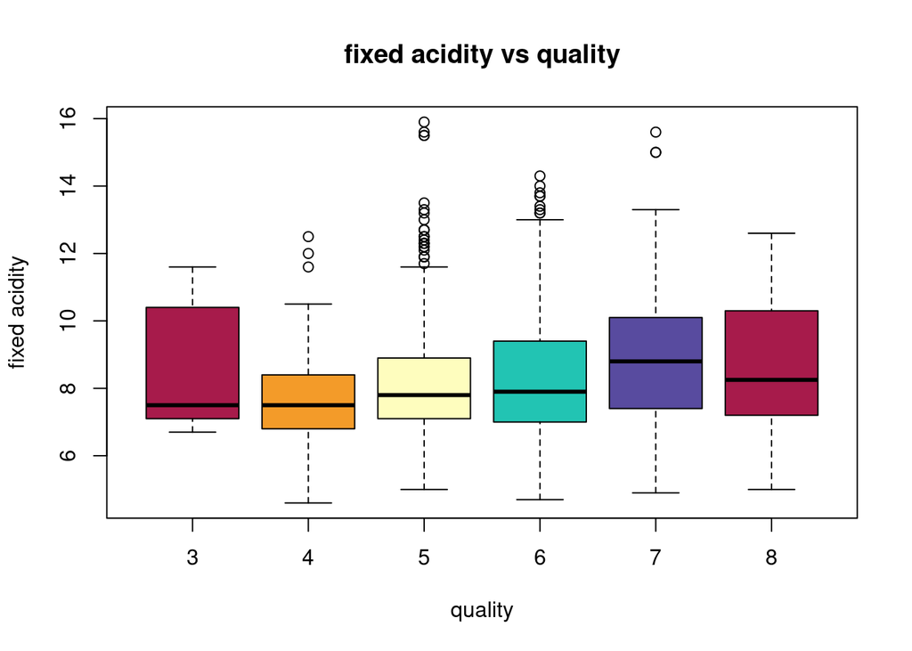

```r
g_caja<-boxplot(data_wine$fixed_acidity~data_wine$quality ,main="fixed acidity vs quality", xlab="quality", ylab="fixed acidity", col=hcl.colors(length(mytable), "Spectral"))
```

```r
valores_outlier<-g_caja$out
g_caja
```

```
## $stats
##      [,1] [,2] [,3] [,4] [,5]  [,6]
## [1,]  6.7  4.6  5.0  4.7  4.9  5.00
## [2,]  7.1  6.8  7.1  7.0  7.4  7.20
## [3,]  7.5  7.5  7.8  7.9  8.8  8.25
## [4,] 10.4  8.4  8.9  9.4 10.1 10.30
## [5,] 11.6 10.5 11.6 13.0 13.3 12.60
##
## $n
## [1]  10  53 681 638 199  18
##
## $conf
##          [,1]     [,2]     [,3]     [,4]     [,5]    [,6]
## [1,] 5.851188 7.152752 7.691018 7.749873 8.497591 7.09553
## [2,] 9.148812 7.847248 7.908982 8.050127 9.102409 9.40447
##
## $out
##  [1] 12.5 11.6 12.0 12.5 13.5 11.9 12.5 12.7 12.3 12.3 12.5 13.0 12.4 11.9 11.9
## [16] 15.5 15.5 15.6 12.7 12.7 12.3 12.3 11.7 13.2 15.9 12.1 13.3 12.2 12.2 13.3
## [31] 13.4 13.8 14.0 13.7 13.7 14.3 13.2 13.2 15.0 15.0 15.6
##
## $group
##  [1] 2 2 2 3 3 3 3 3 3 3 3 3 3 3 3 3 3 3 3 3 3 3 3 3 3 3 3 3 3 4 4 4 4 4 4 4 4 4
## [39] 5 5 5
##
## $names
## [1] "3" "4" "5" "6" "7" "8"
```

```r
#outliers
print(valores_outlier)
```

```
##  [1] 12.5 11.6 12.0 12.5 13.5 11.9 12.5 12.7 12.3 12.3 12.5 13.0 12.4 11.9 11.9
## [16] 15.5 15.5 15.6 12.7 12.7 12.3 12.3 11.7 13.2 15.9 12.1 13.3 12.2 12.2 13.3
## [31] 13.4 13.8 14.0 13.7 13.7 14.3 13.2 13.2 15.0 15.0 15.6
```

- Volatile acidity:

```r
summary(data_wine$volatile_acidity )
```

```
##    Min. 1st Qu.  Median    Mean 3rd Qu.    Max.
##  0.1200  0.3900  0.5200  0.5278  0.6400  1.5800
```

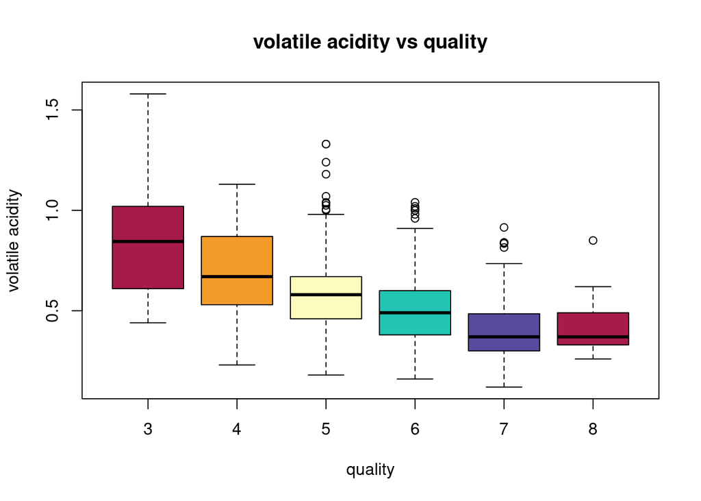

```r
g_caja<-boxplot(data_wine$volatile_acidity~data_wine$quality ,main="volatile acidity vs quality", xlab="quality", ylab="volatile acidity", col=hcl.colors(length(mytable), "Spectral"))
```

```r
valores_outlier<-g_caja$out
g_caja
```

```
## $stats
##       [,1] [,2] [,3] [,4]  [,5] [,6]
## [1,] 0.440 0.23 0.18 0.16 0.120 0.26
## [2,] 0.610 0.53 0.46 0.38 0.300 0.33
## [3,] 0.845 0.67 0.58 0.49 0.370 0.37
## [4,] 1.020 0.87 0.67 0.60 0.485 0.49
## [5,] 1.580 1.13 0.98 0.91 0.735 0.62
##
## $n
## [1]  10  53 681 638 199  18
##
## $conf
##           [,1]      [,2]      [,3]      [,4]      [,5]      [,6]
## [1,] 0.6401477 0.5962099 0.5672854 0.4762384 0.3492794 0.3104145
## [2,] 1.0498523 0.7437901 0.5927146 0.5037616 0.3907206 0.4295855
##
## $out
##  [1] 1.070 1.330 1.330 1.040 1.240 1.035 1.025 1.000 1.005 1.180 1.040 1.000
## [13] 1.000 1.020 0.980 1.010 0.960 0.835 0.815 0.840 0.840 0.915 0.850
##
## $group
##  [1] 3 3 3 3 3 3 3 3 3 3 4 4 4 4 4 4 4 5 5 5 5 5 6
##
## $names
## [1] "3" "4" "5" "6" "7" "8"
```

```r
#outliers
print(valores_outlier)
```

```
##  [1] 1.070 1.330 1.330 1.040 1.240 1.035 1.025 1.000 1.005 1.180 1.040 1.000
## [13] 1.000 1.020 0.980 1.010 0.960 0.835 0.815 0.840 0.840 0.915 0.850
```

- Citric acid:

```r
summary(data_wine$citric_acid )
```

```
##    Min. 1st Qu.  Median    Mean 3rd Qu.    Max.
##   0.000   0.090   0.260   0.271   0.420   1.000
```

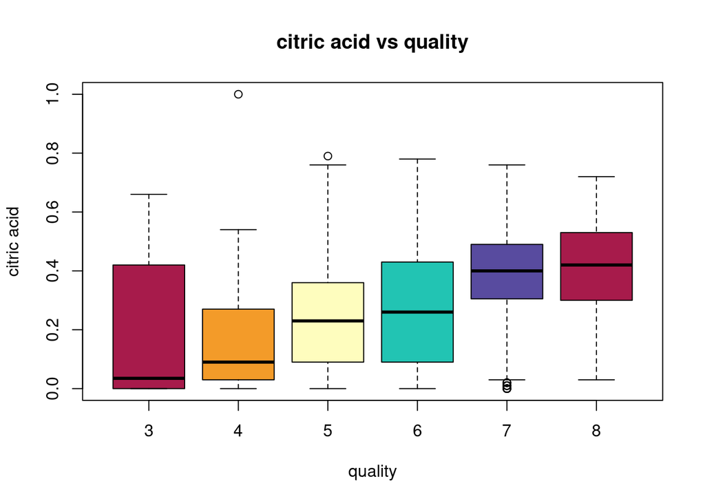

```r
g_caja<-boxplot(data_wine$citric_acid~data_wine$quality ,main="citric acid vs quality", xlab="quality", ylab="citric acid", col=hcl.colors(length(mytable), "Spectral"))
```

```r
valores_outlier<-g_caja$out
g_caja
```

```
## $stats
##       [,1] [,2] [,3] [,4]  [,5] [,6]
## [1,] 0.000 0.00 0.00 0.00 0.030 0.03
## [2,] 0.000 0.03 0.09 0.09 0.305 0.30
## [3,] 0.035 0.09 0.23 0.26 0.400 0.42
## [4,] 0.420 0.27 0.36 0.43 0.490 0.53
## [5,] 0.660 0.54 0.76 0.78 0.760 0.72
##
## $n
## [1]  10  53 681 638 199  18
##
## $conf
##            [,1]       [,2]      [,3]     [,4]      [,5]      [,6]
## [1,] -0.1748487 0.03791287 0.2136527 0.238732 0.3792794 0.3343458
## [2,]  0.2448487 0.14208713 0.2463473 0.281268 0.4207206 0.5056542
##
## $out
##  [1] 1.00 0.79 0.00 0.02 0.01 0.02 0.01 0.00 0.00 0.02 0.00 0.00 0.01 0.01 0.00
## [16] 0.01 0.00 0.00 0.02
##
## $group
##  [1] 2 3 5 5 5 5 5 5 5 5 5 5 5 5 5 5 5 5 5
##
## $names
## [1] "3" "4" "5" "6" "7" "8"
```

```r
#outliers
print(valores_outlier)
```

```
##  [1] 1.00 0.79 0.00 0.02 0.01 0.02 0.01 0.00 0.00 0.02 0.00 0.00 0.01 0.01 0.00
## [16] 0.01 0.00 0.00 0.02
```

- Residual sugar:

```r
summary(data_wine$residual_sugar)
```

```
##    Min. 1st Qu.  Median    Mean 3rd Qu.    Max.
##   0.900   1.900   2.200   2.539   2.600  15.500
```

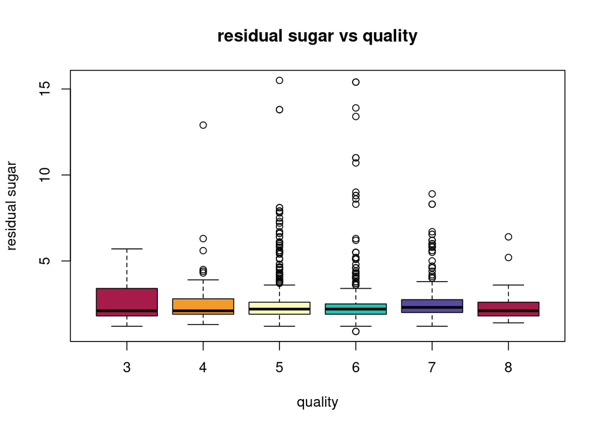

```r
g_caja<-boxplot(data_wine$residual_sugar~data_wine$quality ,main="residual sugar vs quality", xlab="quality", ylab="residual sugar", col=hcl.colors(length(mytable), "Spectral"))
```

```r
valores_outlier<-g_caja$out
g_caja
```

```
## $stats
##      [,1] [,2] [,3] [,4] [,5] [,6]
## [1,]  1.2  1.3  1.2  1.2 1.20  1.4
## [2,]  1.8  1.9  1.9  1.9 2.00  1.8
## [3,]  2.1  2.1  2.2  2.2 2.30  2.1
## [4,]  3.4  2.8  2.6  2.5 2.75  2.6
## [5,]  5.7  3.9  3.6  3.4 3.80  3.6
##
## $n
## [1]  10  53 681 638 199  18
##
## $conf
##          [,1]     [,2]     [,3]     [,4]     [,5]     [,6]
## [1,] 1.300576 1.904673 2.157618 2.162468 2.215998 1.802072
## [2,] 2.899424 2.295327 2.242382 2.237532 2.384002 2.397928
##
## $out
##   [1]  4.40  4.50  4.40  5.60 12.90  4.30  6.30  6.10  6.10  3.80  3.90  5.90
##  [13]  5.90  3.80  5.10  4.65  4.65  5.50  5.50  5.50  5.50  7.30  7.20  3.80
##  [25]  5.60  4.00  7.00  4.50  4.80  7.90  7.90  6.60 15.50  4.60  6.10  5.15
##  [37]  4.20  4.20  4.20  7.90  5.60  5.60  7.50  6.00  3.90  4.00  6.60  4.10
##  [49]  3.90  8.10  8.10  6.40  6.40  3.70  7.80  5.80  4.10  4.50  4.50  4.30
##  [61]  4.30  3.80  5.40  3.80  6.10  3.90  4.80  3.75 13.80 13.80  4.30  6.70
##  [73]  7.80 10.70  5.50  4.00  4.00  4.00  4.00  4.00  3.60 11.00 11.00  3.80
##  [85]  6.20  3.70  4.10  8.30  4.30  6.30  4.60  4.60  4.30  4.30  5.10  8.60
##  [97]  4.20  3.60  3.60  4.00  4.00  3.80  9.00  8.80  8.80  0.90  0.90  5.50
## [109]  5.50  4.30  4.60 13.40  4.80  5.10  5.10 15.40 15.40  5.20  5.20  4.10
## [121]  4.10  4.40  3.70 13.90  5.10  3.60  5.60  5.60  5.80  5.80  4.40  4.20
## [133]  6.70  6.55  6.55  5.80  4.60  6.00  6.00  6.00  4.60  5.00  4.10  5.90
## [145]  6.20  8.90  4.00  4.00  8.30  8.30  4.70  5.50  6.20  6.40  5.20
##
## $group
##   [1] 2 2 2 2 2 2 2 3 3 3 3 3 3 3 3 3 3 3 3 3 3 3 3 3 3 3 3 3 3 3 3 3 3 3 3 3 3
##  [38] 3 3 3 3 3 3 3 3 3 3 3 3 3 3 3 3 3 3 3 3 3 3 3 3 3 3 3 3 3 3 3 3 3 3 3 3 4
##  [75] 4 4 4 4 4 4 4 4 4 4 4 4 4 4 4 4 4 4 4 4 4 4 4 4 4 4 4 4 4 4 4 4 4 4 4 4 4
## [112] 4 4 4 4 4 4 4 4 4 4 4 4 4 4 4 5 5 5 5 5 5 5 5 5 5 5 5 5 5 5 5 5 5 5 5 5 5
## [149] 5 5 5 5 5 6 6
##
## $names
## [1] "3" "4" "5" "6" "7" "8"
```

```r
#outliers
print(valores_outlier)
```

```
##   [1]  4.40  4.50  4.40  5.60 12.90  4.30  6.30  6.10  6.10  3.80  3.90  5.90
##  [13]  5.90  3.80  5.10  4.65  4.65  5.50  5.50  5.50  5.50  7.30  7.20  3.80
##  [25]  5.60  4.00  7.00  4.50  4.80  7.90  7.90  6.60 15.50  4.60  6.10  5.15
##  [37]  4.20  4.20  4.20  7.90  5.60  5.60  7.50  6.00  3.90  4.00  6.60  4.10
##  [49]  3.90  8.10  8.10  6.40  6.40  3.70  7.80  5.80  4.10  4.50  4.50  4.30
##  [61]  4.30  3.80  5.40  3.80  6.10  3.90  4.80  3.75 13.80 13.80  4.30  6.70
##  [73]  7.80 10.70  5.50  4.00  4.00  4.00  4.00  4.00  3.60 11.00 11.00  3.80
##  [85]  6.20  3.70  4.10  8.30  4.30  6.30  4.60  4.60  4.30  4.30  5.10  8.60
##  [97]  4.20  3.60  3.60  4.00  4.00  3.80  9.00  8.80  8.80  0.90  0.90  5.50
## [109]  5.50  4.30  4.60 13.40  4.80  5.10  5.10 15.40 15.40  5.20  5.20  4.10
## [121]  4.10  4.40  3.70 13.90  5.10  3.60  5.60  5.60  5.80  5.80  4.40  4.20
## [133]  6.70  6.55  6.55  5.80  4.60  6.00  6.00  6.00  4.60  5.00  4.10  5.90
## [145]  6.20  8.90  4.00  4.00  8.30  8.30  4.70  5.50  6.20  6.40  5.20
```

- Chlorides :

```r
summary(data_wine$chlorides )
```

```
##    Min. 1st Qu.  Median    Mean 3rd Qu.    Max.
## 0.01200 0.07000 0.07900 0.08747 0.09000 0.61100
```

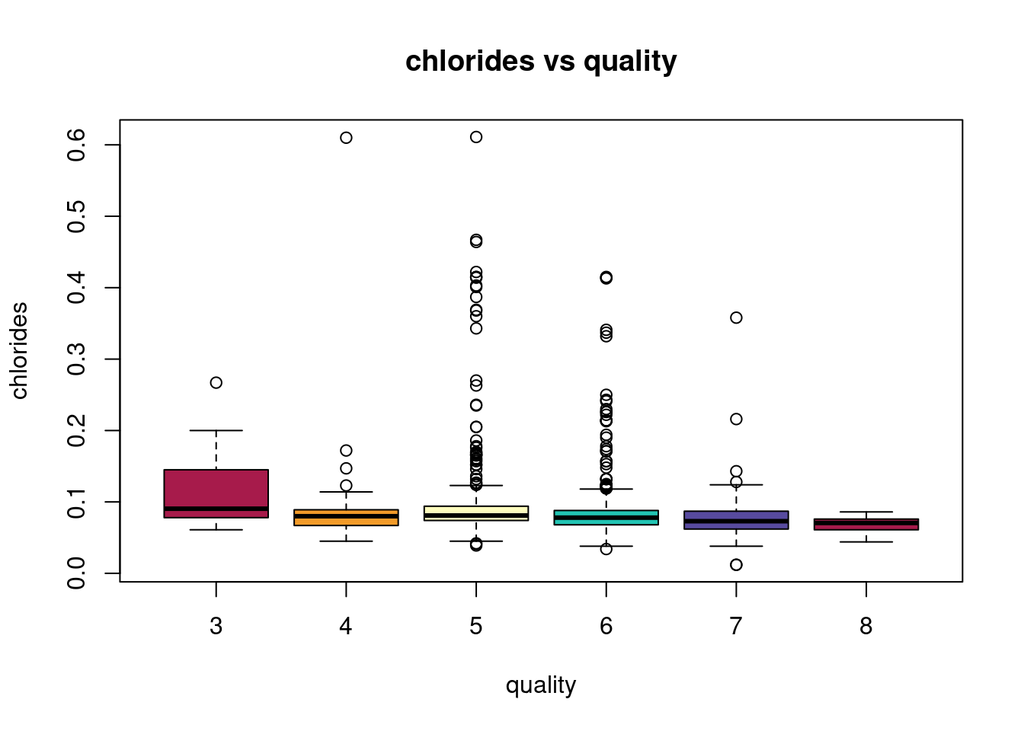

```r
g_caja<-boxplot(data_wine$chlorides~data_wine$quality ,main="chlorides vs quality", xlab="quality", ylab="chlorides", col=hcl.colors(length(mytable), "Spectral"))
```

```r
valores_outlier<-g_caja$out
g_caja
```

```
## $stats
##        [,1]  [,2]  [,3]  [,4]  [,5]   [,6]
## [1,] 0.0610 0.045 0.045 0.038 0.038 0.0440
## [2,] 0.0780 0.067 0.074 0.068 0.062 0.0610
## [3,] 0.0905 0.080 0.081 0.078 0.073 0.0705
## [4,] 0.1450 0.089 0.094 0.088 0.087 0.0760
## [5,] 0.2000 0.114 0.123 0.118 0.124 0.0860
##
## $n
## [1]  10  53 681 638 199  18
##
## $conf
##            [,1]       [,2]       [,3]       [,4]       [,5]       [,6]
## [1,] 0.05702413 0.07522535 0.07978909 0.07674894 0.07019992 0.06491386
## [2,] 0.12397587 0.08477465 0.08221091 0.07925106 0.07580008 0.07608614
##
## $out
##  [1] 0.267 0.172 0.610 0.147 0.123 0.176 0.170 0.368 0.464 0.401 0.467 0.178
## [13] 0.146 0.236 0.360 0.270 0.263 0.611 0.343 0.186 0.159 0.127 0.152 0.152
## [25] 0.124 0.124 0.039 0.157 0.422 0.387 0.132 0.126 0.165 0.161 0.414 0.369
## [37] 0.041 0.166 0.166 0.136 0.403 0.166 0.168 0.415 0.415 0.169 0.205 0.205
## [49] 0.042 0.235 0.341 0.332 0.119 0.119 0.337 0.213 0.214 0.122 0.122 0.174
## [61] 0.121 0.413 0.125 0.171 0.226 0.226 0.250 0.148 0.222 0.034 0.415 0.157
## [73] 0.157 0.243 0.241 0.190 0.119 0.194 0.132 0.120 0.123 0.123 0.171 0.178
## [85] 0.132 0.132 0.123 0.123 0.414 0.153 0.214 0.214 0.230 0.358 0.128 0.143
## [97] 0.012 0.012 0.216
##
## $group
##  [1] 1 2 2 2 2 3 3 3 3 3 3 3 3 3 3 3 3 3 3 3 3 3 3 3 3 3 3 3 3 3 3 3 3 3 3 3 3 3
## [39] 3 3 3 3 3 3 3 3 3 3 3 3 4 4 4 4 4 4 4 4 4 4 4 4 4 4 4 4 4 4 4 4 4 4 4 4 4 4
## [77] 4 4 4 4 4 4 4 4 4 4 4 4 4 4 4 4 4 5 5 5 5 5 5
##
## $names
## [1] "3" "4" "5" "6" "7" "8"
```

```r
#outliers
print(valores_outlier)
```

```
##  [1] 0.267 0.172 0.610 0.147 0.123 0.176 0.170 0.368 0.464 0.401 0.467 0.178
## [13] 0.146 0.236 0.360 0.270 0.263 0.611 0.343 0.186 0.159 0.127 0.152 0.152
## [25] 0.124 0.124 0.039 0.157 0.422 0.387 0.132 0.126 0.165 0.161 0.414 0.369
## [37] 0.041 0.166 0.166 0.136 0.403 0.166 0.168 0.415 0.415 0.169 0.205 0.205
## [49] 0.042 0.235 0.341 0.332 0.119 0.119 0.337 0.213 0.214 0.122 0.122 0.174
## [61] 0.121 0.413 0.125 0.171 0.226 0.226 0.250 0.148 0.222 0.034 0.415 0.157
## [73] 0.157 0.243 0.241 0.190 0.119 0.194 0.132 0.120 0.123 0.123 0.171 0.178
## [85] 0.132 0.132 0.123 0.123 0.414 0.153 0.214 0.214 0.230 0.358 0.128 0.143
## [97] 0.012 0.012 0.216
```

- Free sulfur dioxide :

```r
summary(data_wine$free_sulfur_dioxide )
```

```
##    Min. 1st Qu.  Median    Mean 3rd Qu.    Max.
##    1.00    7.00   14.00   15.87   21.00   72.00
```

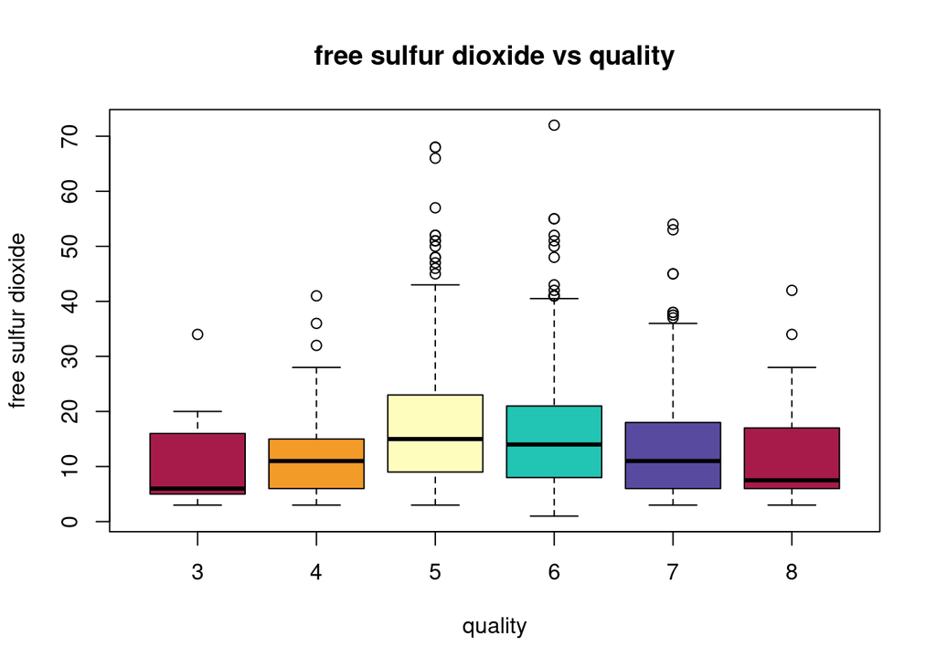

```r
g_caja<-boxplot(data_wine$free_sulfur_dioxide~data_wine$quality ,main="free sulfur dioxide vs quality", xlab="quality", ylab="free sulfur dioxide", col=hcl.colors(length(mytable), "Spectral"))
```

```r
valores_outlier<-g_caja$out
g_caja
```

```
## $stats
##      [,1] [,2] [,3] [,4] [,5] [,6]
## [1,]    3    3    3  1.0    3  3.0
## [2,]    5    6    9  8.0    6  6.0
## [3,]    6   11   15 14.0   11  7.5
## [4,]   16   15   23 21.0   18 17.0
## [5,]   20   28   43 40.5   36 28.0
##
## $n
## [1]  10  53 681 638 199  18
##
## $conf
##            [,1]      [,2]     [,3]     [,4]      [,5]      [,6]
## [1,]  0.5039614  9.046733 14.15236 13.18681  9.655961  3.403495
## [2,] 11.4960386 12.953267 15.84764 14.81319 12.344039 11.596505
##
## $out
##  [1] 34.0 41.0 32.0 36.0 52.0 51.0 50.0 68.0 68.0 47.0 46.0 45.0 57.0 48.0 51.0
## [16] 51.0 52.0 48.0 48.0 66.0 41.0 41.0 41.0 52.0 51.0 41.0 50.0 48.0 41.0 43.0
## [31] 72.0 55.0 55.0 42.0 38.0 38.0 54.0 53.0 45.0 37.5 37.5 45.0 37.0 34.0 42.0
##
## $group
##  [1] 1 2 2 2 3 3 3 3 3 3 3 3 3 3 3 3 3 3 3 3 4 4 4 4 4 4 4 4 4 4 4 4 4 4 5 5 5 5
## [39] 5 5 5 5 5 6 6
##
## $names
## [1] "3" "4" "5" "6" "7" "8"
```

```r
#outliers
print(valores_outlier)
```

```
##  [1] 34.0 41.0 32.0 36.0 52.0 51.0 50.0 68.0 68.0 47.0 46.0 45.0 57.0 48.0 51.0
## [16] 51.0 52.0 48.0 48.0 66.0 41.0 41.0 41.0 52.0 51.0 41.0 50.0 48.0 41.0 43.0
## [31] 72.0 55.0 55.0 42.0 38.0 38.0 54.0 53.0 45.0 37.5 37.5 45.0 37.0 34.0 42.0
```

- Total sulfur dioxide :

```r
summary(data_wine$total_sulfur_dioxide )
```

```
##    Min. 1st Qu.  Median    Mean 3rd Qu.    Max.
##    6.00   22.00   38.00   46.47   62.00  289.00
```

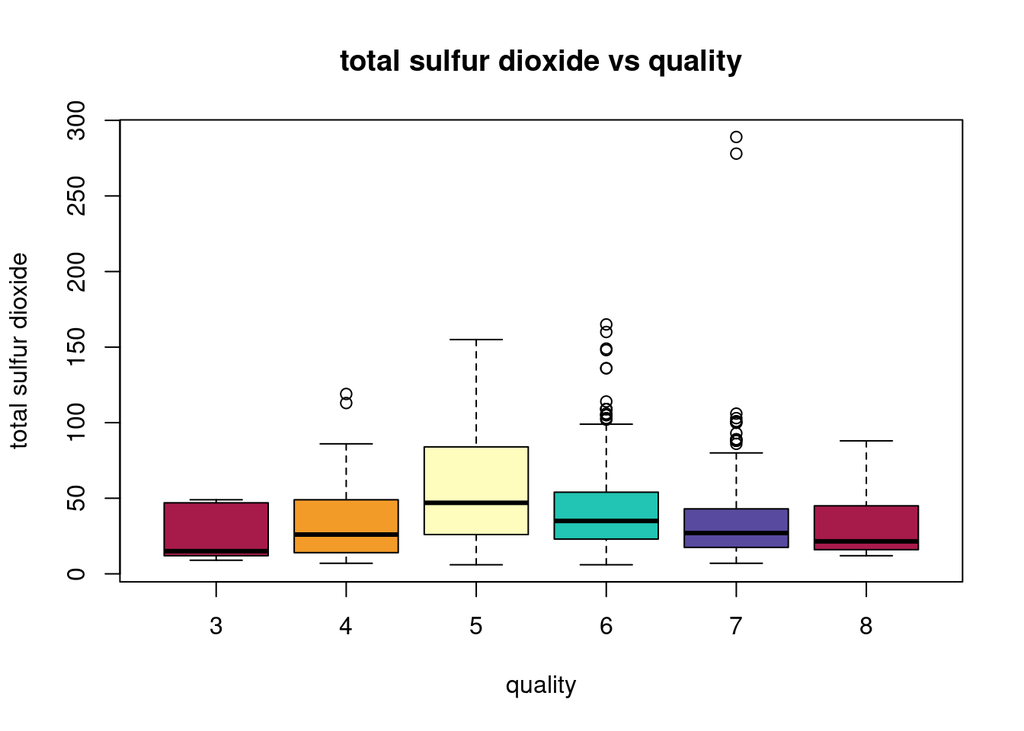

```r
g_caja<-boxplot(data_wine$total_sulfur_dioxide~data_wine$quality ,main="total sulfur dioxide vs quality", xlab="quality", ylab="total sulfur dioxide", col=hcl.colors(length(mytable), "Spectral"))
```

```r
valores_outlier<-g_caja$out
g_caja
```

```
## $stats
##      [,1] [,2] [,3] [,4] [,5] [,6]
## [1,]    9    7    6    6  7.0 12.0
## [2,]   12   14   26   23 17.5 16.0
## [3,]   15   26   47   35 27.0 21.5
## [4,]   47   49   84   54 43.0 45.0
## [5,]   49   86  155   99 80.0 88.0
##
## $n
## [1]  10  53 681 638 199  18
##
## $conf
##           [,1]     [,2]     [,3]     [,4]     [,5]     [,6]
## [1,] -2.487395 18.40396 43.48835 33.06086 24.14392 10.70012
## [2,] 32.487395 33.59604 50.51165 36.93914 29.85608 32.29988
##
## $out
##  [1] 119 113 136 136 106 109 105 114 165 149 103 148 109 109 160 105 102 103  93
## [20] 106  86 100 100 278 289  88 101  88  89  89
##
## $group
##  [1] 2 2 4 4 4 4 4 4 4 4 4 4 4 4 4 4 4 5 5 5 5 5 5 5 5 5 5 5 5 5
##
## $names
## [1] "3" "4" "5" "6" "7" "8"
```

```r
#outliers
print(valores_outlier)
```

```
##  [1] 119 113 136 136 106 109 105 114 165 149 103 148 109 109 160 105 102 103  93
## [20] 106  86 100 100 278 289  88 101  88  89  89
```

- Density :

```r
summary(data_wine$density )
```

```
##    Min. 1st Qu.  Median    Mean 3rd Qu.    Max.
##  0.9901  0.9956  0.9968  0.9967  0.9978  1.0037
```

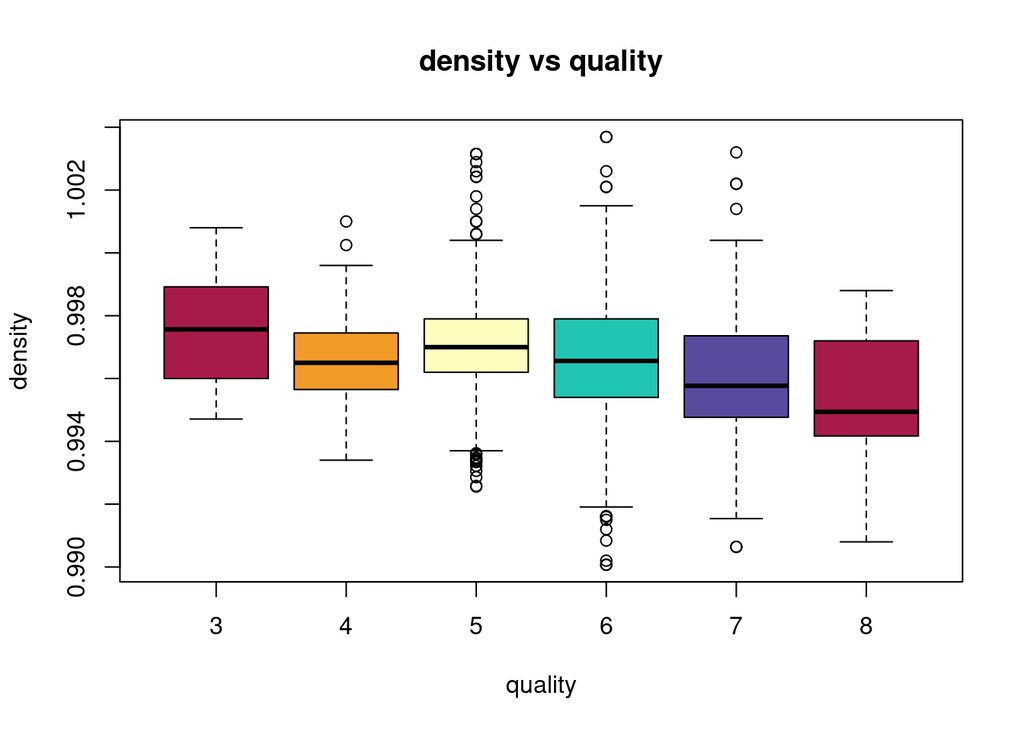

```r
g_caja<-boxplot(data_wine$density~data_wine$quality ,main="density vs quality", xlab="quality", ylab="density", col=hcl.colors(length(mytable), "Spectral"))
```

```r
valores_outlier<-g_caja$out
g_caja
```

```
## $stats
##          [,1]    [,2]   [,3]    [,4]     [,5]    [,6]
## [1,] 0.994710 0.99340 0.9937 0.99191 0.991540 0.99080
## [2,] 0.996000 0.99565 0.9962 0.99540 0.994765 0.99417
## [3,] 0.997565 0.99650 0.9970 0.99656 0.995770 0.99494
## [4,] 0.998920 0.99745 0.9979 0.99790 0.997360 0.99720
## [5,] 1.000800 0.99960 1.0004 1.00150 1.000400 0.99880
##
## $n
## [1]  10  53 681 638 199  18
##
## $conf
##           [,1]      [,2]      [,3]      [,4]      [,5]      [,6]
## [1,] 0.9961061 0.9961093 0.9968971 0.9964036 0.9954794 0.9938116
## [2,] 0.9990239 0.9968907 0.9971029 0.9967164 0.9960606 0.9960684
##
## $out
##  [1] 1.00025 1.00100 1.00100 1.00180 1.00140 1.00060 1.00260 1.00100 0.99340
## [10] 1.00315 1.00315 1.00315 1.00060 1.00060 1.00100 1.00289 0.99258 0.99256
## [19] 0.99341 0.99346 0.99358 0.99286 0.99322 0.99334 0.99336 1.00242 1.00242
## [28] 0.99348 0.99306 0.99362 0.99160 0.99160 0.99120 1.00210 1.00210 1.00260
## [37] 0.99162 0.99007 0.99007 0.99020 0.99150 0.99084 1.00369 1.00369 1.00220
## [46] 1.00220 1.00320 1.00140 0.99064 0.99064
##
## $group
##  [1] 2 2 3 3 3 3 3 3 3 3 3 3 3 3 3 3 3 3 3 3 3 3 3 3 3 3 3 3 3 3 4 4 4 4 4 4 4 4
## [39] 4 4 4 4 4 4 5 5 5 5 5 5
##
## $names
## [1] "3" "4" "5" "6" "7" "8"
```

```r
#outliers
print(valores_outlier)
```

```
##  [1] 1.00025 1.00100 1.00100 1.00180 1.00140 1.00060 1.00260 1.00100 0.99340
## [10] 1.00315 1.00315 1.00315 1.00060 1.00060 1.00100 1.00289 0.99258 0.99256
## [19] 0.99341 0.99346 0.99358 0.99286 0.99322 0.99334 0.99336 1.00242 1.00242
## [28] 0.99348 0.99306 0.99362 0.99160 0.99160 0.99120 1.00210 1.00210 1.00260
## [37] 0.99162 0.99007 0.99007 0.99020 0.99150 0.99084 1.00369 1.00369 1.00220
## [46] 1.00220 1.00320 1.00140 0.99064 0.99064
```

- PH :

```r
summary(data_wine$pH )
```

```
##    Min. 1st Qu.  Median    Mean 3rd Qu.    Max.
##   2.740   3.210   3.310   3.311   3.400   4.010
```

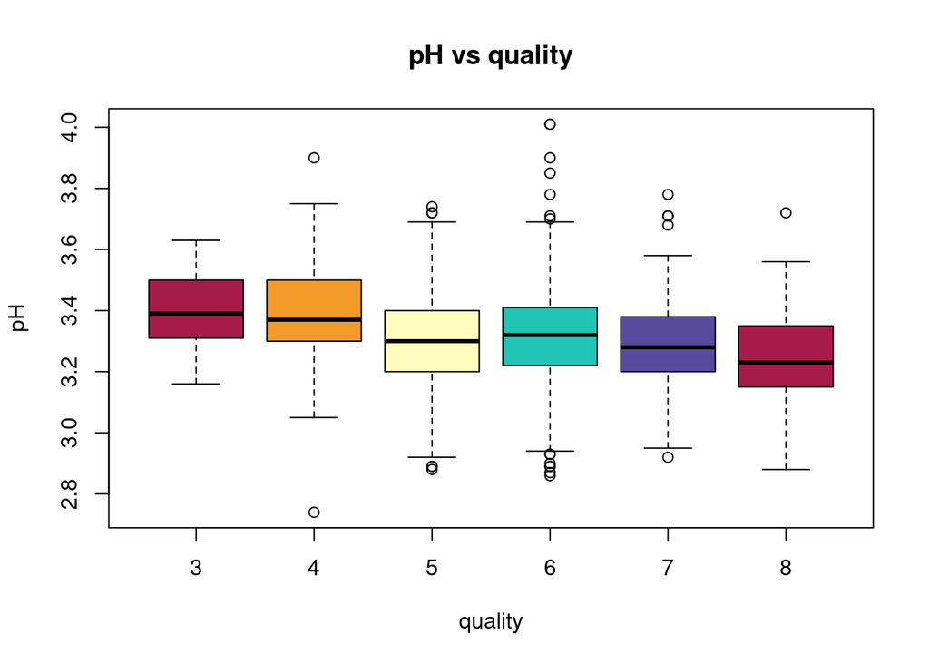

```r
g_caja<-boxplot(data_wine$pH~data_wine$quality ,main="pH vs quality", xlab="quality", ylab="pH", col=hcl.colors(length(mytable), "Spectral"))
```